# DA1102_Finance slides

```python
from __future__ import division
from pandas import Series, DataFrame
import pandas as pd
from numpy.random import randn
import numpy as np
pd.options.display.max_rows = 12
np.set_printoptions(precision=4, suppress=True)
import matplotlib.pyplot as plt
plt.rc('figure', figsize=(12, 6))
pd.reset_option('precision')
pd.set_option('chop_threshold', 0)
```

```python
from IPython.display import display, HTML

CSS = """
.output {
    flex-direction: row;
}
"""

HTML('<style>{}</style>'.format(CSS))
```

```python
%matplotlib inline
```

```python
%pwd
```

```
'C:\\Users\\Sulhee Baek\\Documents\\PythonDataAnalysis'
```

```python
pd.options.display.max_rows = 100
pd.options.display.max_columns = 10
np.random.seed(12345)
```

# 금융, 경제 데이터 애플리케이션

## 그룹 변환과 분석

다음의 가상 주식 포트폴리오를 생각해보자. 먼저 임의로 1000개의 주식 종목을 생성한다.

```python
import random; random.seed(0)
import string

N = 1000
def rands(n):
    choices = string.ascii_uppercase
    return ''.join([random.choice(choices) for _ in range(n)])
tickers = np.array([rands(5) for _ in range(N)])
```

각 주식 종목에 사용할 3개의 칼럼을 가지는 DataFrame을 생성한다.

```python
M = 500
df = DataFrame({'Momentum' : np.random.randn(M) / 200 + 0.03,
                'Value' : np.random.randn(M) / 200 + 0.08,
                'ShortInterest' : np.random.randn(M) / 200 - 0.02},
                index=tickers[:M])
```

주식 종목을 위한 임의의 산업 테마 2개를 생성하여 이를 Series에 저장한다.

```python
ind_names = np.array(['FINANCIAL', 'TECH'])
sampler = np.random.randint(0, len(ind_names), N)
industries = Series(ind_names[sampler], index=tickers,
                    name='industry')
```

산업 테마별(industries)로 그룹 집계와 변환을 수행할 수 있다.

```python
by_industry = df.groupby(industries)
by_industry.mean()
```

| industry | Momentum | ShortInterest | Value |
| --- | --- | --- | --- |
| FINANCIAL | 0.029485 | -0.020739 | 0.079929 |
| TECH | 0.030407 | -0.019609 | 0.080113 |

```python
by_industry.describe()
```

| industry | Momentum count | Momentum mean | Momentum std | Momentum min | Momentum 25% | ... | Value min | Value 25% | Value 50% | Value 75% | Value max |
| --- | --- | --- | --- | --- | --- | --- | --- | --- | --- | --- | --- |
| FINANCIAL | 246.0 | 0.029485 | 0.004802 | 0.017210 | 0.026263 | ... | 0.067025 | 0.076638 | 0.079804 | 0.082718 | 0.093334 |
| TECH | 254.0 | 0.030407 | 0.005303 | 0.016778 | 0.026456 | ... | 0.065253 | 0.076737 | 0.080296 | 0.083353 | 0.093081 |

2 rows × 24 columns

변환 함수를 정의하면 이 포트폴리오를 산업 테마별로 쉽게 변환할 수 있다. 예를 들어 산업 테마 표준화는 주식 포트폴리오를 만들 때 널리 사용된다.

```python
# 산업 테마 표준화
def zscore(group):
    return (group - group.mean()) / group.std()

df_stand = by_industry.apply(zscore)
```

각 산업 테마의 평균은 0이고 표준편차는 1임을 확인할 수 있다.

```python
df_stand.groupby(industries).agg(['mean', 'std'])
```

| industry | Momentum mean | Momentum std | ShortInterest mean | ShortInterest std | Value mean | Value std |
| --- | --- | --- | --- | --- | --- | --- |
| FINANCIAL | 1.114736e-15 | 1.0 | 3.081772e-15 | 1.0 | 8.001278e-15 | 1.0 |
| TECH | -2.779929e-16 | 1.0 | -1.910982e-15 | 1.0 | -7.139521e-15 | 1.0 |

rank 메소드를 이용하면 편리하게 산업 테마별 최소/최대값을 구할 수 있다.

```python
# 산업 테마별 순위, 내림차순
ind_rank = by_industry.rank(ascending=False)
ind_rank.groupby(industries).agg(['min', 'max'])
```

| industry | Momentum min | Momentum max | ShortInterest min | ShortInterest max | Value min | Value max |
| --- | --- | --- | --- | --- | --- | --- |
| FINANCIAL | 1.0 | 246.0 | 1.0 | 246.0 | 1.0 | 246.0 |
| TECH | 1.0 | 254.0 | 1.0 | 254.0 | 1.0 | 254.0 |

주식 투자에서 *순위와 표준화*는 흔히 사용되는 변환 절차이다. 다음처럼 rank와 zscore를 함께 연계해서 구할 수도 있다.

```python
# Industry rank and standardize
by_industry.apply(lambda x: zscore(x.rank()))
```

|  | Momentum | ShortInterest | Value |
| --- | --- | --- | --- |
| MYNBI | -0.091346 | -0.976696 | -1.004802 |
| QPMZJ | 0.794005 | 1.299919 | -0.358356 |
| PLSGQ | -0.541047 | -0.836164 | -1.679355 |
| EJEYD | -0.583207 | -1.623142 | 0.990749 |
| TZIRW | 1.572120 | -0.265423 | 0.374314 |
| ZTEJD | 1.395171 | 0.360703 | -1.436006 |
| XCVKP | -0.074863 | 0.632931 | -0.660154 |
| RDLNK | 0.238200 | -0.319869 | 0.102086 |
| TUGRP | 1.075068 | 1.665302 | 1.580983 |
| OQIBZ | 1.412345 | 0.358356 | -1.313972 |
| RACXM | 1.229653 | 1.257760 | -0.822111 |
| WZVUA | -1.426398 | -0.625366 | -0.934536 |
| TPKHX | 0.224589 | -0.156531 | 1.313503 |
| KWCGS | 0.142920 | 0.741823 | 0.619320 |
| HHZEZ | 1.538823 | 0.597260 | -1.566930 |
| ROCCK | 1.117228 | -1.510717 | 0.428622 |
| QPDJR | -1.640177 | 0.700989 | 0.755434 |
| JWDRK | -0.537651 | 1.572120 | 0.714600 |
| RGZTR | 1.637195 | -0.555101 | 0.442675 |
| SJOCT | -0.619320 | -0.469594 | 0.088474 |
| ZMKSH | -0.555101 | 0.259984 | -1.468557 |
| JFGFB | 0.524040 | -0.496817 | -1.721846 |
| TVIPC | 1.708234 | 0.034029 | 0.796269 |
| CVYEE | -1.259057 | 0.673766 | 0.115697 |
| BCWRV | -0.639420 | 0.920483 | 1.426398 |
| MWQIQ | -0.020417 | -1.612954 | -1.626566 |
| ZHGVS | 0.265423 | 1.177388 | 1.272668 |
| NSIOP | 0.836164 | 1.552876 | 1.679355 |
| VUWZL | -0.142920 | -0.564874 | -0.306257 |
| CKTDP | 1.496664 | 0.302143 | -1.257760 |

[output cut: 71 more lines]

500 rows × 3 columns

### 그룹 요인 밝히기

요인 분석은 양적 포트폴리오 관리에서 사용되는 기법이다. 포트폴리오 자산과 실적(이익과 손해)은 포트폴리오 가중치로 표현되는 하나 이상의 요인으로 분리된다. 예를 들어 S&P 500 지수 같은 기준에 따른 주가의 움직임이 종목의 민감도가 되며 일반적인 위험 요인이다. 임의로 생성된 세 가지 요인(인자 부하)과 가중치를 가지고 만든 가상의 포트폴리오 예제를 살펴보자.

```python
from numpy.random import rand
fac1, fac2, fac3 = np.random.rand(3, 1000)

ticker_subset = tickers.take(np.random.permutation(N)[:1000])

# Weighted sum of factors plus noise
port = Series(0.7 * fac1 - 1.2 * fac2 + 0.3 * fac3 + rand(1000),
              index=ticker_subset)
factors = DataFrame({'f1': fac1, 'f2': fac2, 'f3': fac3},
                    index=ticker_subset)
```

요인과 포트폴리오 사이의 벡터 상관관계는 뚜렷이 나타나지 않을 수 있다.

```python
factors.corrwith(port)
```

```
f1    0.402377
f2   -0.680980
f3    0.168083
dtype: float64
```

요인을 밝히기 위해 최소자승(OLS) 회귀분석을 적용해본다 그룹별 DataFrame인 chunk와 factors를 statsmodels.api의 OLS 메소드에 넘겨서 그룹별 요인을 밝힐 수 있다.

```python
import statsmodels.api as sm
```

```python
def beta_exposure(chunk, factors=None):
    print ('\n[description of chunk]:\n', chunk.describe())
    print ('\n[description of factors]:\n', factors.describe())
    new_factors = factors.reindex(index=chunk.index)
    new_factors['intercept'] = 1.
    model = sm.OLS(chunk, new_factors)
    results = model.fit()
    return results.params
```

```python
by_ind = port.groupby(industries)
```

```python
exposures = by_ind.apply(beta_exposure, factors=factors)
```

```
[description of chunk]:
 count    470.000000
mean       0.411958
std        0.497183
min       -0.873909
25%        0.075204
50%        0.389495
75%        0.757689
max        1.714177
Name: FINANCIAL, dtype: float64

[description of factors]:
                 f1           f2           f3
count  1000.000000  1000.000000  1000.000000
mean      0.507042     0.499180     0.498433
std       0.280803     0.291997     0.292830
min       0.001568     0.000877     0.001231
25%       0.265069     0.233095     0.236267
50%       0.507966     0.500560     0.490136
75%       0.752556     0.762266     0.755446
max       0.996193     0.996215     0.998763

[description of chunk]:
 count    530.000000
mean       0.411708
std        0.517920
min       -0.950941
25%        0.032163
50%        0.376912
75%        0.780956
max        1.656204
Name: TECH, dtype: float64

[description of factors]:
                 f1           f2           f3
count  1000.000000  1000.000000  1000.000000
mean      0.507042     0.499180     0.498433
std       0.280803     0.291997     0.292830
min       0.001568     0.000877     0.001231
25%       0.265069     0.233095     0.236267
50%       0.507966     0.500560     0.490136
75%       0.752556     0.762266     0.755446
max       0.996193     0.996215     0.998763
```

```python
exposures.unstack()
```

| industry | f1 | f2 | f3 | intercept |
| --- | --- | --- | --- | --- |
| FINANCIAL | 0.790329 | -1.182970 | 0.275624 | 0.455569 |
| TECH | 0.740857 | -1.232882 | 0.303811 | 0.508188 |

### 십분위와 사분위 분석

표본 변위치에 기반한 분석은 금융 분석에서 중요한 분석 방법 중 하나이다. 예를 들어 주식 포트폴리오의 실적은 주식 가격과 수익에 기반하여 분기별로 나누어 계산할 수 있다. pandas.qcut과 groupby를 함께 사용하면 손쉽게 사분위 분석을 할 수 있다.

애플의 주가 예제를 살펴보자.

```python
data = pd.read_pickle('ch05/yahoo_price.pkl')
data.tail()
```

| Date | AAPL | GOOG | IBM | MSFT |
| --- | --- | --- | --- | --- |
| 2016-10-17 | 117.550003 | 779.960022 | 154.770004 | 57.220001 |
| 2016-10-18 | 117.470001 | 795.260010 | 150.720001 | 57.660000 |
| 2016-10-19 | 117.120003 | 801.500000 | 151.259995 | 57.529999 |
| 2016-10-20 | 117.059998 | 796.969971 | 151.520004 | 57.250000 |
| 2016-10-21 | 116.599998 | 799.369995 | 149.630005 | 59.660000 |

```python
px = data['AAPL'] # 애플 주가만 색인
returns = px.pct_change() # 수익률 (주가의 일별 퍼센트 변화율)
```

일별 수익을 계산하는 함수

```python
def to_index(rets):
    index = (1 + rets).cumprod()
    first_loc = max(index.index.get_loc(index.idxmax()) - 1, 0)
    index.values[first_loc] = 1
    return index
```

수익을 추세 신호로 변환하는 함수

```python
def trend_signal(rets, lookback, lag):
    signal = rets.rolling(lookback, min_periods=lookback-5).sum()
    return signal.shift(lag)
```

```python
signal = trend_signal(returns, 100, 3)
trade_friday = signal.resample('W-FRI').resample('B').ffill()
trade_rets = trade_friday.shift(1) * returns
trade_rets = trade_rets[:len(returns)]
```

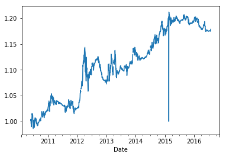

```python
to_index(trade_rets).plot()
plt.show()
```

```python
vol = returns.rolling(250, min_periods=200).std() * np.sqrt(250)

def sharpe(rets, ann=250):
    return rets.mean() / rets.std()  * np.sqrt(ann)
```

```python
cats = pd.qcut(vol, 4)
print('cats: %d, trade_rets: %d, vol: %d' % (len(cats), len(trade_rets), len(vol)))
```

```
cats: 1714, trade_rets: 1714, vol: 1714
```

```python
trade_rets.groupby(cats).agg(sharpe)
```

```
AAPL
(0.205, 0.237]    0.709342
(0.237, 0.263]    0.184075
(0.263, 0.281]    0.308896
(0.281, 0.327]    0.738210
Name: AAPL, dtype: float64
```

## 추가 예제 애플리케이션

### 신호 경계 분석

```python
px = pd.read_csv('ch11/stock_px.csv', index_col=0, parse_dates=True)
```

```python
plt.close('all')
```

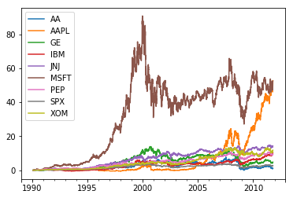

```python
px = px.asfreq('B').fillna(method='pad')
rets = px.pct_change()
((1 + rets).cumprod() - 1).plot()
plt.show()
```

```python
def calc_mom(price, lookback, lag):
    mom_ret = price.shift(lag).pct_change(lookback)
    ranks = mom_ret.rank(axis=1, ascending=False)
    demeaned = ranks.subtract(ranks.mean(axis=1), axis=0)
    return demeaned.divide(demeaned.std(axis=1), axis=0)
```

```python
compound = lambda x : (1 + x).prod() - 1
daily_sr = lambda x: x.mean() / x.std()

def strat_sr(prices, lb, hold):
    # Compute portfolio weights
    freq = '%dB' % hold
    port = calc_mom(prices, lb, lag=1)

    daily_rets = prices.pct_change()

    # Compute portfolio returns
    port = port.shift(1).resample(freq).first()
    returns = daily_rets.resample(freq).compound()
    port_rets = (port * returns).sum(axis=1)

    return daily_sr(port_rets) * np.sqrt(252 / hold)
```

```python
strat_sr(px, 70, 30)
```

```
-0.7924730462012824
```

```python
from collections import defaultdict

lookbacks = range(20, 90, 5)
holdings = range(20, 90, 5)
dd = defaultdict(dict)
for lb in lookbacks:
    for hold in holdings:
        dd[lb][hold] = strat_sr(px, lb, hold)

ddf = DataFrame(dd)
ddf.index.name = 'Holding Period'
ddf.columns.name = 'Lookback Period'
```

```python
import matplotlib.pyplot as plt

def heatmap(df, cmap=plt.cm.gray_r):
    fig = plt.figure()
    ax = fig.add_subplot(111)
    axim = ax.imshow(df.values, cmap=cmap, interpolation='nearest')
    ax.set_xlabel(df.columns.name)
    ax.set_xticks(np.arange(len(df.columns)))
    ax.set_xticklabels(list(df.columns))
    ax.set_ylabel(df.index.name)
    ax.set_yticks(np.arange(len(df.index)))
    ax.set_yticklabels(list(df.index))
    plt.colorbar(axim)
```

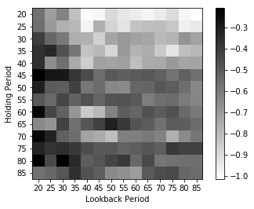

```python
heatmap(ddf)
```

### 선물 계약 롤링

```python
pd.options.display.max_rows = 20
```

https://finance.yahoo.com에서 SPY 조회결과 다운로드

```python
# Approximate price of S&P 500 index
df = pd.read_csv('ch11/yahoo_spy.csv', parse_dates=True, index_col=0)
display(df.tail())
px = df['Adj Close'] * 10
px
```

| Date | Open | High | Low | Close | Adj Close | Volume |
| --- | --- | --- | --- | --- | --- | --- |
| 2012-07-20 | 136.949997 | 137.160004 | 136.320007 | 136.470001 | 120.900192 | 142904500 |
| 2012-07-23 | 134.470001 | 136.380005 | 133.839996 | 135.089996 | 119.677650 | 145210900 |
| 2012-07-24 | 135.190002 | 135.250000 | 133.029999 | 133.929993 | 118.649971 | 173301200 |
| 2012-07-25 | 134.210007 | 134.559998 | 133.250000 | 133.960007 | 118.676582 | 129122300 |
| 2012-07-26 | 135.889999 | 136.460007 | 135.259995 | 136.169998 | 120.634430 | 156526500 |

```
Date
2006-01-03     982.64160
2006-01-04     987.29507
2006-01-05     987.91534
2006-01-06     996.13632
2006-01-09     998.69576
2006-01-10     999.70367
2006-01-11    1002.88345
2006-01-12     998.92838
2006-01-13     997.99782
2006-01-17     995.28313
                 ...
2012-07-13    1202.62306
2012-07-16    1199.78859
2012-07-17    1208.02765
2012-07-18    1216.97510
2012-07-19    1220.16441
2012-07-20    1209.00192
2012-07-23    1196.77650
2012-07-24    1186.49971
2012-07-25    1186.76582
2012-07-26    1206.34430
Name: Adj Close, Length: 1654, dtype: float64
```

```python
from datetime import datetime
expiry = {'ESU2': datetime(2012, 9, 21),
          'ESZ2': datetime(2012, 12, 21)}
expiry = Series(expiry).sort_values()
```

```python
expiry
```

```
ESU2   2012-09-21
ESZ2   2012-12-21
dtype: datetime64[ns]
```

```python
np.random.seed(12347)
N = 200
walk = (np.random.randint(0, 200, size=N) - 100) * 0.25
perturb = (np.random.randint(0, 20, size=N) - 10) * 0.25
walk = walk.cumsum()

rng = pd.date_range(px.index[0], periods=len(px) + N, freq='B')
near = np.concatenate([px.values, px.values[-1] + walk])
far = np.concatenate([px.values, px.values[-1] + walk + perturb])
prices = DataFrame({'ESU2': near, 'ESZ2': far}, index=rng)
```

```python
prices.tail()
```

|  | ESU2 | ESZ2 |
| --- | --- | --- |
| 2013-02-04 | 1235.5943 | 1237.3443 |
| 2013-02-05 | 1221.8443 | 1224.0943 |
| 2013-02-06 | 1229.8443 | 1231.5943 |
| 2013-02-07 | 1246.3443 | 1245.5943 |
| 2013-02-08 | 1226.3443 | 1224.0943 |

```python
def get_roll_weights(start, expiry, items, roll_periods=5):
    # start : first date to compute weighting DataFrame
    # expiry : Series of ticker -> expiration dates
    # items : sequence of contract names

    dates = pd.date_range(start, expiry[-1], freq='B')
    weights = DataFrame(np.zeros((len(dates), len(items))),
                        index=dates, columns=items)

    prev_date = weights.index[0]
    for i, (item, ex_date) in enumerate(expiry.iteritems()):
        if i < len(expiry) - 1:
            weights.loc[prev_date:ex_date - pd.offsets.BDay(), item] = 1
            roll_rng = pd.date_range(end=ex_date - pd.offsets.BDay(),
                                     periods=roll_periods + 1, freq='B')

            decay_weights = np.linspace(0, 1, roll_periods + 1)
            weights.loc[roll_rng, item] = 1 - decay_weights
            weights.loc[roll_rng, expiry.index[i + 1]] = decay_weights
        else:
            weights.loc[prev_date:, item] = 1

        prev_date = ex_date

    return weights
```

```python
weights = get_roll_weights('6/1/2012', expiry, prices.columns)
weights.loc['2012-09-12':'2012-09-21']
```

|  | ESU2 | ESZ2 |
| --- | --- | --- |
| 2012-09-12 | 1.0 | 0.0 |
| 2012-09-13 | 1.0 | 0.0 |
| 2012-09-14 | 0.8 | 0.2 |
| 2012-09-17 | 0.6 | 0.4 |
| 2012-09-18 | 0.4 | 0.6 |
| 2012-09-19 | 0.2 | 0.8 |
| 2012-09-20 | 0.0 | 1.0 |
| 2012-09-21 | 0.0 | 1.0 |

```python
rolled_returns = (prices.pct_change() * weights).sum(1)
rolled_returns
```

```
2006-01-03    0.0
2006-01-04    0.0
2006-01-05    0.0
2006-01-06    0.0
2006-01-09    0.0
2006-01-10    0.0
2006-01-11    0.0
2006-01-12    0.0
2006-01-13    0.0
2006-01-16    0.0
             ...
2013-01-28    0.0
2013-01-29    0.0
2013-01-30    0.0
2013-01-31    0.0
2013-02-01    0.0
2013-02-04    0.0
2013-02-05    0.0
2013-02-06    0.0
2013-02-07    0.0
2013-02-08    0.0
Freq: B, Length: 1854, dtype: float64
```

### 롤링 상관관계와 선형 회귀

```python
px = pd.read_csv('ch11/stock_px.csv', parse_dates=True, index_col=0)
px
```

|  | AA | AAPL | GE | IBM | JNJ | MSFT | PEP | SPX | XOM |
| --- | --- | --- | --- | --- | --- | --- | --- | --- | --- |
| 1990-02-01 | 4.98 | 7.86 | 2.87 | 16.79 | 4.27 | 0.51 | 6.04 | 328.79 | 6.12 |
| 1990-02-02 | 5.04 | 8.00 | 2.87 | 16.89 | 4.37 | 0.51 | 6.09 | 330.92 | 6.24 |
| 1990-02-05 | 5.07 | 8.18 | 2.87 | 17.32 | 4.34 | 0.51 | 6.05 | 331.85 | 6.25 |
| 1990-02-06 | 5.01 | 8.12 | 2.88 | 17.56 | 4.32 | 0.51 | 6.15 | 329.66 | 6.23 |
| 1990-02-07 | 5.04 | 7.77 | 2.91 | 17.93 | 4.38 | 0.51 | 6.17 | 333.75 | 6.33 |
| 1990-02-08 | 5.04 | 7.71 | 2.92 | 17.86 | 4.46 | 0.51 | 6.22 | 332.96 | 6.35 |
| 1990-02-09 | 5.06 | 8.00 | 2.94 | 17.82 | 4.49 | 0.52 | 6.24 | 333.62 | 6.37 |
| 1990-02-12 | 4.96 | 7.94 | 2.89 | 17.58 | 4.46 | 0.52 | 6.23 | 330.08 | 6.22 |
| 1990-02-13 | 4.91 | 8.06 | 2.88 | 17.95 | 4.43 | 0.52 | 6.09 | 331.02 | 6.23 |
| 1990-02-14 | 4.94 | 8.00 | 2.89 | 18.04 | 4.47 | 0.52 | 6.10 | 332.01 | 6.20 |
| ... | ... | ... | ... | ... | ... | ... | ... | ... | ... |
| 2011-10-03 | 8.90 | 374.60 | 14.69 | 173.29 | 62.08 | 24.53 | 60.29 | 1099.23 | 71.15 |
| 2011-10-04 | 9.12 | 372.50 | 14.86 | 174.74 | 62.17 | 25.34 | 60.45 | 1123.95 | 72.83 |
| 2011-10-05 | 9.37 | 378.25 | 15.27 | 176.85 | 62.35 | 25.89 | 60.29 | 1144.03 | 73.95 |
| 2011-10-06 | 9.88 | 377.37 | 15.53 | 181.69 | 62.81 | 26.34 | 60.57 | 1164.97 | 73.89 |
| 2011-10-07 | 9.71 | 369.80 | 15.50 | 182.39 | 63.13 | 26.25 | 61.02 | 1155.46 | 73.56 |
| 2011-10-10 | 10.09 | 388.81 | 16.14 | 186.62 | 64.43 | 26.94 | 61.87 | 1194.89 | 76.28 |
| 2011-10-11 | 10.30 | 400.29 | 16.14 | 185.00 | 63.96 | 27.00 | 60.95 | 1195.54 | 76.27 |
| 2011-10-12 | 10.05 | 402.19 | 16.40 | 186.12 | 64.33 | 26.96 | 62.70 | 1207.25 | 77.16 |
| 2011-10-13 | 10.10 | 408.43 | 16.22 | 186.82 | 64.23 | 27.18 | 62.36 | 1203.66 | 76.37 |
| 2011-10-14 | 10.26 | 422.00 | 16.60 | 190.53 | 64.72 | 27.27 | 62.24 | 1224.58 | 78.11 |

5472 rows × 9 columns

```python
start = '2009-01-01'
end = '2012-06-01'
names = ['AAPL', 'GOOG', 'MSFT', 'GS', 'MS', 'BAC', 'C']
data = DataFrame()
for name in names:
    filename = 'ch11/'+name+'.csv'
    df = pd.read_csv(filename, parse_dates=True, index_col=0)[['Adj Close']][start:end]
    df.columns = [name]
    if len(data) > 0:
        data = pd.concat([data, df], axis=1, )
    else:
        data = df
```

```python
data
```

| Date | AAPL | GOOG | MSFT | GS | MS | BAC | C |
| --- | --- | --- | --- | --- | --- | --- | --- |
| 2009-01-02 | 8.742546 | 159.621811 | 15.996102 | 76.698608 | 14.799498 | 13.243549 | 68.645760 |
| 2009-01-05 | 9.111515 | 162.965073 | 16.145594 | 78.484337 | 15.348276 | 12.920083 | 68.068916 |
| 2009-01-06 | 8.961231 | 165.950653 | 16.334438 | 78.422478 | 17.055571 | 13.197339 | 71.722313 |
| 2009-01-07 | 8.767592 | 159.964584 | 15.350908 | 74.700706 | 15.766388 | 12.670556 | 68.741882 |
| 2009-01-08 | 8.930403 | 161.544312 | 15.830869 | 75.505180 | 16.393562 | 12.513443 | 68.838028 |
| 2009-01-09 | 8.726168 | 156.517014 | 15.358771 | 74.187958 | 16.602613 | 12.005142 | 64.896194 |
| 2009-01-12 | 8.541201 | 155.334702 | 15.319429 | 68.662773 | 16.367432 | 10.563418 | 53.839798 |
| 2009-01-13 | 8.449681 | 156.144424 | 15.594819 | 68.883766 | 16.428400 | 9.842552 | 56.724083 |
| 2009-01-14 | 8.220403 | 149.512558 | 15.020442 | 66.912376 | 14.973718 | 9.426673 | 43.552559 |
| 2009-01-15 | 8.032544 | 148.528961 | 15.138462 | 65.268066 | 14.163618 | 7.689207 | 36.822575 |
| ... | ... | ... | ... | ... | ... | ... | ... |
| 2012-05-17 | 51.069954 | 309.511932 | 25.411055 | 88.997879 | 12.218740 | 6.540660 | 25.434525 |
| 2012-05-18 | 51.095005 | 298.260101 | 25.026304 | 87.540230 | 12.118883 | 6.578142 | 25.049301 |
| 2012-05-21 | 54.071804 | 305.070801 | 25.436708 | 88.475319 | 11.973638 | 6.400103 | 25.280434 |
| 2012-05-22 | 53.656597 | 298.458801 | 25.445253 | 89.410393 | 12.082574 | 6.540660 | 25.925682 |
| 2012-05-23 | 54.965813 | 302.760834 | 24.889498 | 89.877937 | 12.137036 | 6.718701 | 26.147188 |
| 2012-05-24 | 54.461002 | 299.879578 | 24.855295 | 88.796173 | 12.082574 | 6.690589 | 25.675297 |
| 2012-05-25 | 54.169106 | 293.853760 | 24.846748 | 88.649529 | 12.028102 | 6.699960 | 25.492310 |
| 2012-05-29 | 55.130554 | 295.249695 | 25.274254 | 90.141731 | 12.382139 | 6.971706 | 26.021994 |
| 2012-05-30 | 55.795258 | 292.214417 | 25.086149 | 87.148048 | 11.882859 | 6.755894 | 25.039669 |
| 2012-05-31 | 55.656551 | 288.553253 | 24.957899 | 88.152077 | 12.127961 | 6.896641 | 25.530830 |

860 rows × 7 columns

```python
aapl = pd.read_csv('ch11/AAPL_corr.csv', parse_dates=True, index_col=0)['Adj Close']
msft = pd.read_csv('ch11/MSFT_corr.csv', parse_dates=True, index_col=0)['Adj Close']

aapl_rets = aapl.pct_change()
msft_rets = msft.pct_change()
```

```python
plt.figure()
```

애플과 마이크로소프트의 연간 상관관계

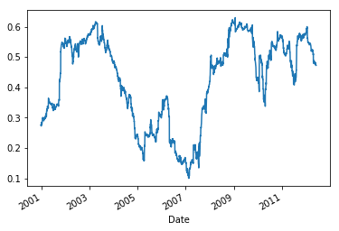

```python
aapl_rets.rolling(250).corr(msft_rets).plot()
plt.show()
```

```python
plt.figure()
```

```python
import statsmodels.api as sm
y = aapl_rets[1:]
X = DataFrame({'MSFT':msft_rets[1:]})
X['intercept'] = 1.

model = sm.OLS(y, X, window=250)
results = model.fit()
```

```python
sm.OLS?
```

```
Init signature: sm.OLS(endog, exog=None, missing='none', hasconst=None, **kwargs)
Docstring:
A simple ordinary least squares model.


Parameters
----------
endog : array-like
    1-d endogenous response variable. The dependent variable.
exog : array-like
    A nobs x k array where `nobs` is the number of observations and `k`
    is the number of regressors. An intercept is not included by default
    and should be added by the user. See
    :func:`statsmodels.tools.add_constant`.
missing : str
    Available options are 'none', 'drop', and 'raise'. If 'none', no nan
    checking is done. If 'drop', any observations with nans are dropped.
    If 'raise', an error is raised. Default is 'none.'
hasconst : None or bool
    Indicates whether the RHS includes a user-supplied constant. If True,
    a constant is not checked for and k_constant is set to 1 and all
    result statistics are calculated as if a constant is present. If
    False, a constant is not checked for and k_constant is set to 0.


Attributes
----------
weights : scalar
    Has an attribute weights = array(1.0) due to inheritance from WLS.
```

```python
results.params
```

```
MSFT         0.597538
intercept    0.001432
dtype: float64
```

```python
results.tvalues
```

```
MSFT         26.498512
intercept     2.973059
dtype: float64
```

```python
results.params['MSFT']
```

```
0.5975375776949938
```